# Who Answers the Pollster?

**Diagnosing non-ignorable nonresponse with a randomised response instrument**

Ben Stanley

SWPS University

September 17, 2026

## Surveys have a problem

- Response rates have collapsed: in a typical Polish online (CAWI) panel survey, **fewer than one invitee in ten** completes the questionnaire.
- Everything we report — turnout forecasts, party support, attitudes to democracy — comes from the small, self-selected group that *chose* to answer.
- The standard repair is **weighting**: adjust the sample until it matches the population on age, gender, education and place of residence.
- Weighting rests on one enormous assumption: **people who answer are just like the people who don’t — once demographics match.**

## When the assumption fails: non-ignorable nonresponse

- For many questions the assumption is fine. For some it fails badly: **the answer itself is linked to the willingness to respond.**
  - The politically engaged love political surveys — and they vote more.
  - The distrustful avoid pollsters — and they hold distinctive views.
- This is **non-ignorable nonresponse** (Bailey 2024): the missing differ in their *opinions*, not just their demographics — a problem invisible to demographic weights.

## The synthetic world

- We simulate a country of 100,000 people, so the true answers are **known exactly**.
- Two hidden traits drive both *whether* people respond and *what* they think:
  - **political engagement** — ↑ response; ↑ turnout, pro-minority and pro-democratic answers;
  - **institutional trust** — ↑ response; ↓ support for a stigmatised anti-establishment party.
- Six survey items: four where the hidden traits matter (**flagged**), two that depend on demographics only (**controls**: EU support, smoking).
- We field a survey among 30,000 randomly invited people — with one trick built in.

## The design: randomise the contact protocol

```
flowchart LR
    I["30,000 invitees<br>(random sample)"] --> R{{"random<br>50 / 50"}}
    R --> A["<b>Arm A — standard contact</b><br>invitation + reminders + bonus points"]
    R --> B["<b>Arm B — light contact</b><br>one bare invitation, then silence"]
    A --> RA["20.7% respond (n = 3,096)<br><i>eager <b>and</b> reluctant types</i>"]
    B --> RB["5.7% respond (n = 853)<br><i>only the most eager types</i>"]
    style A fill:#e8e8e8,stroke:#555
    style B fill:#fdeceb,stroke:#9B0000
```

- **Compare their answers, question by question**: same answers → nonresponse ignorable, weighting fine; different answers → bias detected.
- This randomly assigned nudge is a **randomised response instrument** (Bailey 2024, ch. 10): it moves *whether* people respond without touching *what they think*.

## Why the respondent mean goes wrong

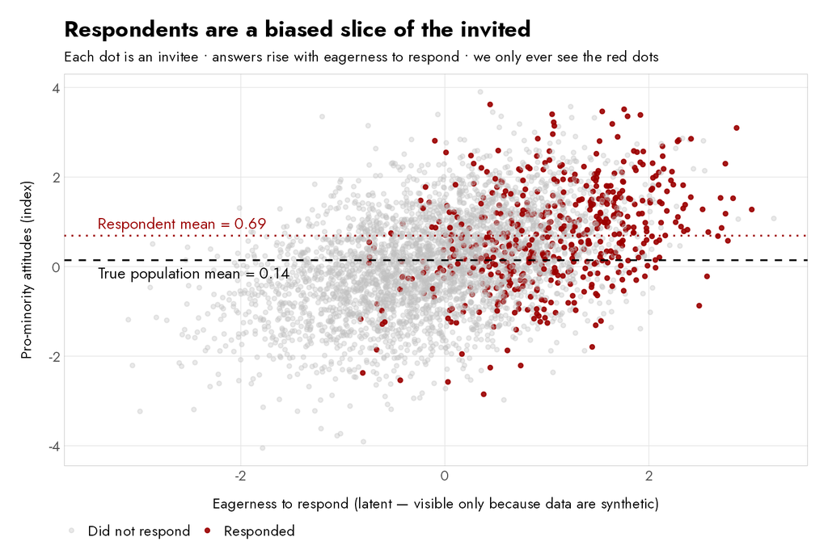

# Results

## Step 1 — the instrument works

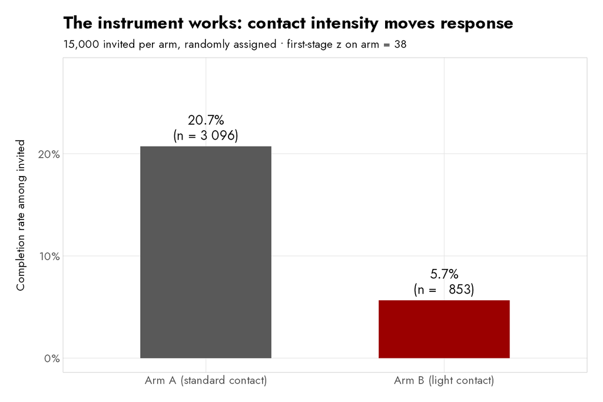

- A **15-point response-rate gap** from randomly assigned contact intensity: the *inclusion condition* holds.

## Step 2 — the arms disagree exactly where they should

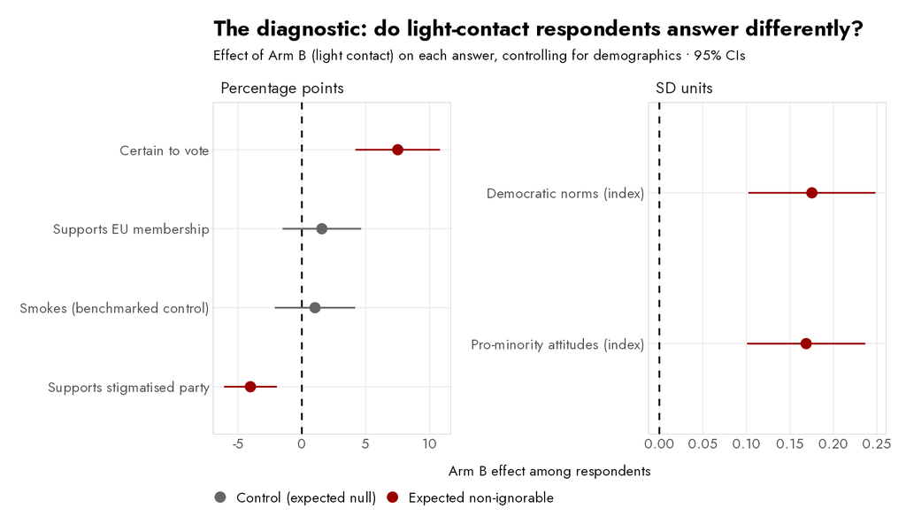

Light-contact respondents report **more** turnout (+7.5 pp), **less** stigmatised-party support (-4 pp) and **more** progressive attitudes — while both controls sit at zero.

## Step 3 — weighting does not rescue the flagged items

| Item | Truth | Observed poll | After raking | Still off by |
| --- | --- | --- | --- | --- |
| Certain to vote | 49.9% | 69.5% | 68.9% | **+19 pp** |
| Stigmatised party | 19.7% | 10.4% | 10.1% | **−9.6 pp** |
| Pro-minority index | 0.14 | 0.69 | 0.64 | **+0.5** |
| EU support (control) | 76.9% | 77.9% | 77.2% | ✓ fine |
| Smoking (control) | 21.9% | 21.8% | 22% | ✓ fine |

- Raking matches the sample to the population on every demographic — and moves the flagged estimates barely at all.

## Step 4 — selection models plus the instrument recover the truth

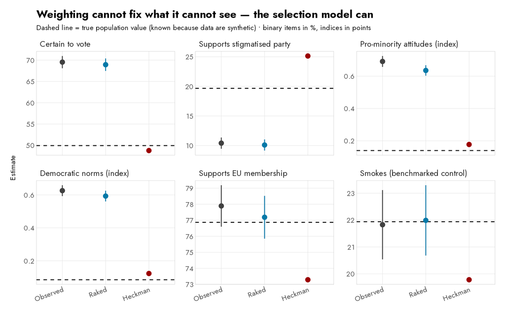

## Reading the results like Bailey’s decision tree

| Item | ρ̂ (selection–outcome correlation) | Verdict | Correct tool |
| --- | --- | --- | --- |
| Certain to vote | 0.33 (z = 4.7) | non-ignorable | selection model |
| Stigmatised party | -0.36 (z = -4) | non-ignorable | selection model |
| Pro-minority index | 0.28 (z = 5.1) | non-ignorable | selection model |
| Democratic norms | 0.29 (z = 5.1) | non-ignorable | selection model |
| EU support | 0.08 (z = 0.9) | ignorable | **keep weighting** |
| Smoking | 0.05 (z = 0.6) | ignorable | **keep weighting** |

- Where ρ̂ ≈ 0, weighting is *better* — selection models add noise you do not need.

## Polls exaggerate polarisation

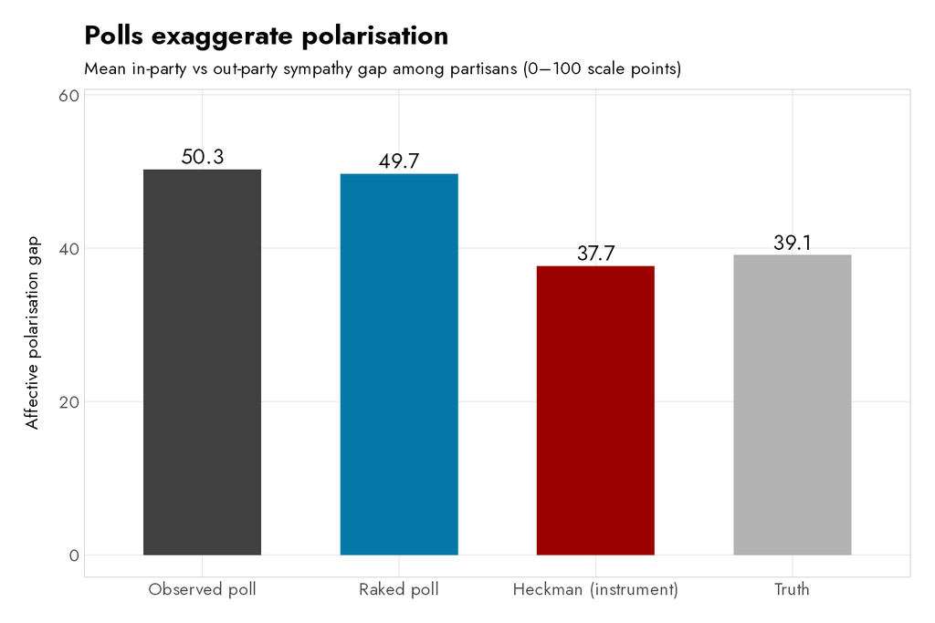

Engaged partisans respond more *and* feel more hostility towards the other side, so the observed gap (50.3) overstates the true one (39.1). Bailey found precisely this in the US: eager Democrats and eager Republicans are both more extreme than their quieter co-partisans.

## The FRBN pilot

- **~2,000 completes** from a Polish CAWI panel; ~18,500 invitations randomised 42/58 into **intensive** (invitation + three reminders) vs **light** contact; the agency tags every interview with its arm and reminder wave.
- Questionnaire mixes items expected to be affected by non-ignorable nonresponse bias (turnout, stigmatised parties, minorities, democratic norms) with **controls** — including items benchmarked against official statistics and election results.
- **Pre-registered** hypotheses, tests and decision rules; full code and anonymised data published.
- Output: for each construct, **how strongly response propensity is tied to the answer, with an interval** — plus a **validated, reusable protocol** for PGSW and the effect sizes a full-scale study needs.

## What a pilot this size can and cannot settle

- The analysis was built and run on **simulated data before fieldwork** — which is how we found that two reminders would have left the key tests detecting the expected effects about **one time in ten**.
- The binding constraint is the **response-rate gap**, not the number of completes: sample size buys √n, the contact protocol buys the gap. Hence three reminders, and a go/no-go at the soft launch set on power rather than on instrument validity.
- Even so: expect some items to come back **indeterminate**. The honest product is the estimate and its interval, not a verdict on every question.
- That is what a pilot is for — and it is exactly what an NCN OPUS proposal needs in order to be properly powered.